title: “Untitled” author: “Талапов Н./Абдулина Л.”

# Задание 1

Прочитайте файл в переменную. На основе полученных данных создайте новую переменную в которой будут следующие колонки (наблюдения): ‘Year’, ‘P99’, ‘P99.5’ и ‘P99.9’; это уровни дохода ,которые входят в 99-й, 99.5-й и 99.9 персентиль дохода. Чему равнялся P99 в 1972? P99.5 в 1942? P99.9 в 1922? Требуется найти эти значения с помощью кода, а не с помощью глаз (для удобства разумно будет переименовать колонки в данных).

```r
wtid<-read.csv('https://raw.githubusercontent.com/SergeyMirvoda/da2016/master/lab6/wtid-report.csv')
wtid.f<-data.frame(Y=wtid$Year,P99=wtid$P99.income.threshold,P99.5=wtid$P99.5.income.threshold,P99.9=wtid$P99.9.income.threshold)
wtid.f$P99[wtid.f$Y==1972]
```

```
## [1] 209076.6
```

```r
wtid.f$P99.5[wtid.f$Y==1942]
```

```
## [1] 183217
```

```r
wtid.f$P99.9[wtid.f$Y==1922]
```

```
## [1] 400214.2
```

Постройте диаграмму рассеяний всех трёх персентилей относительно времени. Проверьте, чтобы метки осей были корректными и на оси x были годы от 1913 до 2012.

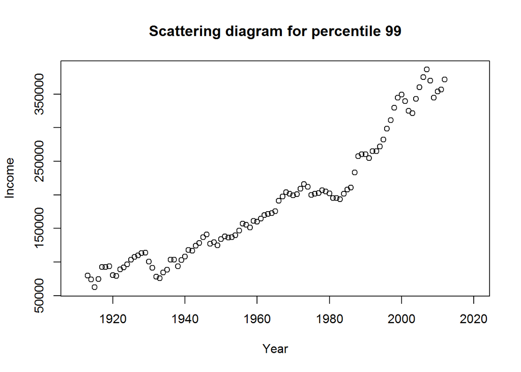

```r
plot(wtid.f$Y,wtid.f$P99, xlab = 'Year', type="p", ylab = 'Income', xlim=c(1910, 2020), main='Scattering diagram for percentile 99')
```

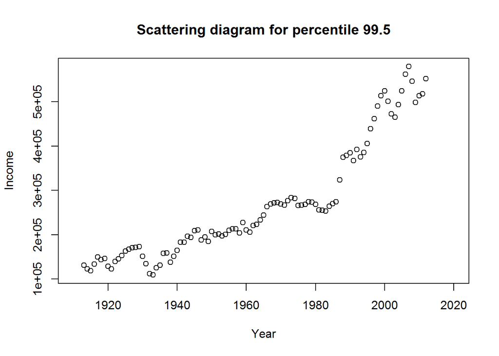

```r
plot(wtid.f$Y,wtid.f$P99.5, xlab = 'Year', type="p", ylab = 'Income', xlim=c(1910, 2020),main='Scattering diagram for percentile 99.5')
```

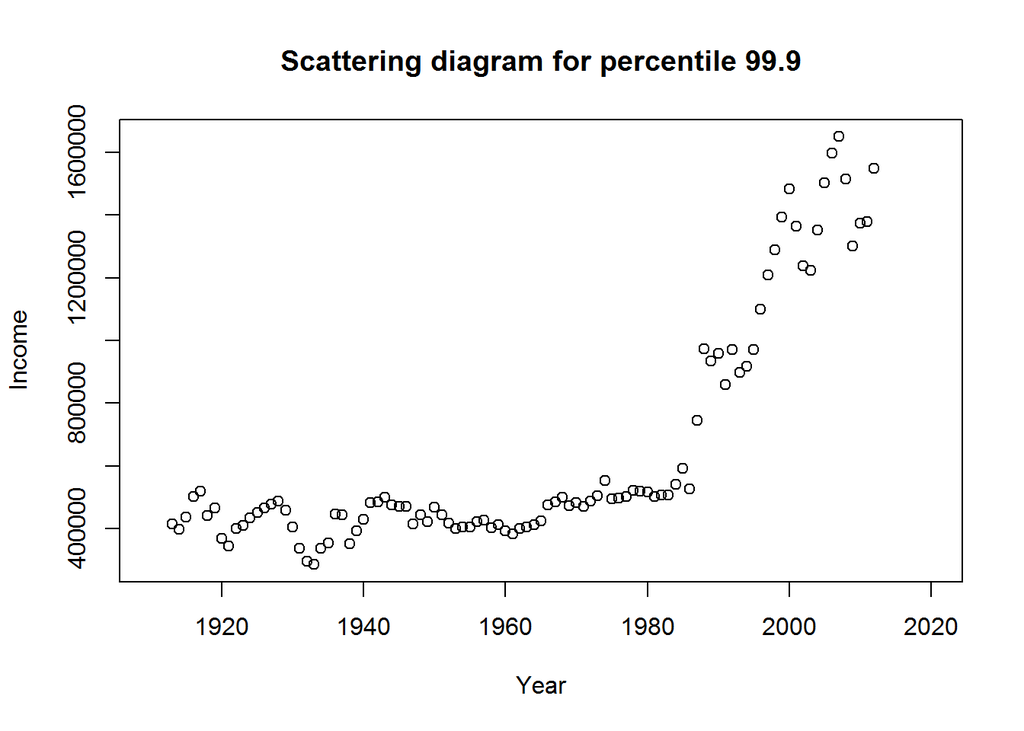

```r
plot(wtid.f$Y,wtid.f$P99.9, xlab = 'Year', type="p", ylab = 'Income', xlim=c(1910, 2020),main='Scattering diagram for percentile 99.9')
```

Из предыдущих вычислений можно получить, что оценить параметр a можно по следующей формуле: a = 1 - log(10)/log(P99/P99.9) (3). Напишите функцию my.exp.estimate_ratio, которая принимает аргументы P99 и P99.9 и возвращает a, рассчитанное по формуле (3). Проверьте, что при P99 = 1e6 и P99.9 = 1e7 функция вернёт a = 2.

```r
my.exp.estimate_ratio<-function(data,P99,P99.9){
return(a = 1 - log(10)/log(P99/P99.9))
}
my.exp.estimate_ratio(wtid.f,10^6,10^7)
```

```
## [1] 2
```

# Задание 2

Получите значение a для каждого года в наборе данных. Если функция написана корректно вам не понадобятся циклы. Постройте график а относительно годов. Что можно сказать по полученному графику, соотносится ли это с тем, что имеется на самом деле?(Имейте ввиду, чем экспонента меньше, тем выше неравенство)

```r
vecA<-data.frame(a=my.exp.estimate_ratio(wtid.f,wtid.f$P99,wtid.f$P99.9))
wtid.f$A<-vecA$a
wtid.f
```

```
##        Y       P99    P99.5     P99.9        A
## 1   1913  80087.90 131337.2  415206.4 2.399194
## 2   1914  74012.72 122935.9  397671.6 2.369454
## 3   1915  62392.24 118717.4  437522.8 2.182215
## 4   1916  74869.18 133777.1  502094.2 2.209948
## 5   1917  92341.21 149697.9  519558.7 2.332909
## 6   1918  92221.06 143219.7  442731.1 2.467761
## 7   1919  93757.35 145819.0  464982.8 2.437956
## 8   1920  80455.37 128494.4  368109.9 2.514182
## 9   1921  79241.83 122271.2  343458.5 2.570057
## 10  1922  88764.67 139003.1  400214.2 2.528930
## 11  1923  91662.86 145284.2  409574.3 2.538132
## 12  1924  96309.09 152595.0  433328.4 2.531042
## 13  1925 103376.02 162548.5  452423.7 2.559757
## 14  1926 107382.55 167234.2  466019.9 2.568699
```

[output cut: 86 more lines]

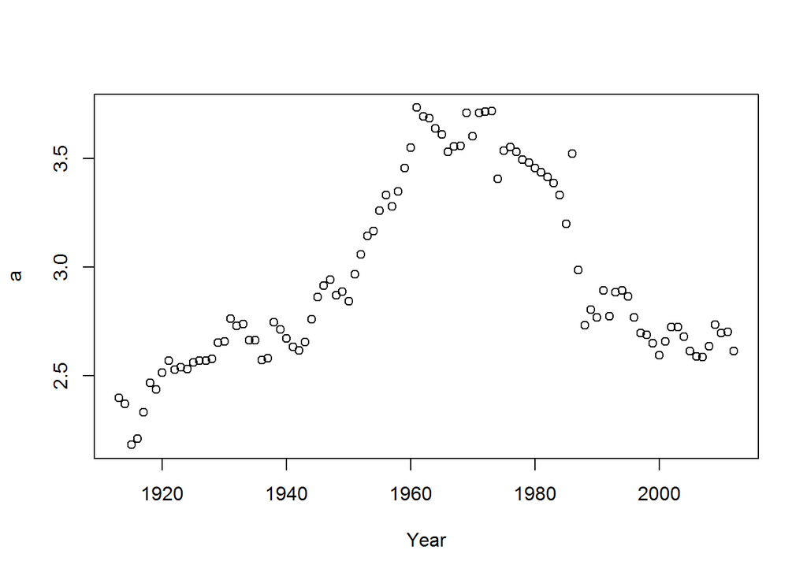

```r
plot(wtid.f$Y,wtid.f$A,xlab='Year',ylab='a')
```

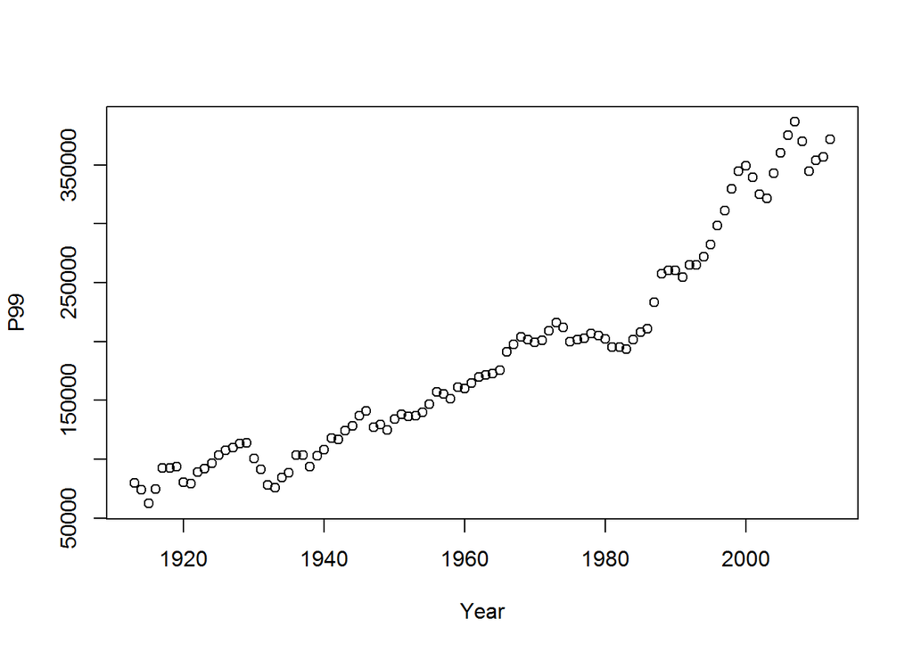

```r
plot(wtid.f$Y,wtid.f$P99,xlab='Year',ylab='P99')
```

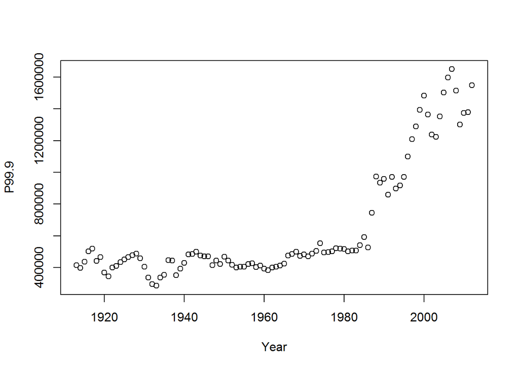

```r
plot(wtid.f$Y,wtid.f$P99.9,xlab='Year',ylab='P99.9')
```

Функция a возрастает когда значение отношения функций P99 от Y к P99.9 от Y возрастает. На 2 и 3 графике видно, что функция P.99 от Y значительно возрастает на протяжении всего периода, когда как функция P99.9 от Y значительно возрастает под конец периода.

Используя полученную для 2012 года оценку параметра a проверьте выполняется ли принцип Парето (20% популяции владеет 80 % богатства) однако зависит от конкретной величины k).

```r
a2012<-wtid.f$A[wtid.f$Y==2012]
fsf<-((a2012-1)/wtid.f$P99.9[wtid.f$Y==2012])*(wtid.f$P99.9[wtid.f$Y==2012]*0.8*wtid.f$P99.9[wtid.f$Y==2012])
```

Из выражения (3) можно вывести следующее: (P99.5/P99.9)^(-a+1) = 5. Напишите функцию, которая будет принимать P99.5, P99.9 и a , и вычислять левую часть выражения. Отобразите полученное на графике. На нём же отобразите горизонтальную прямую с вертикальной координатой равной 5 (при помощи команды abline). Насколько качественно выполнена подгонка модели?

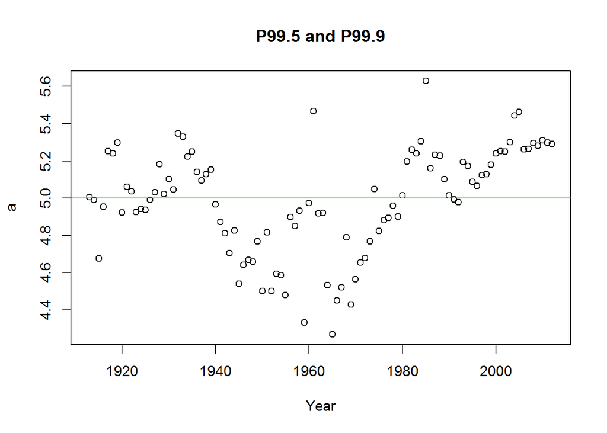

```r
func1<-function(P99.5,P99.9,a){
return((P99.5/P99.9)^(-a+1))
}
plot(wtid.f$Y,func1(wtid.f$P99.5,wtid.f$P99.9,wtid.f$A), xlab='Year',ylab='a', main='P99.5 and P99.9')
abline(h = 5, col = '232323')
```

Тоже самое верно и для: (P90/P95)^(-a+1) = 2. Повторите предыдущее для этой формулы. Что можно сказать, сравнив эти подгонки?

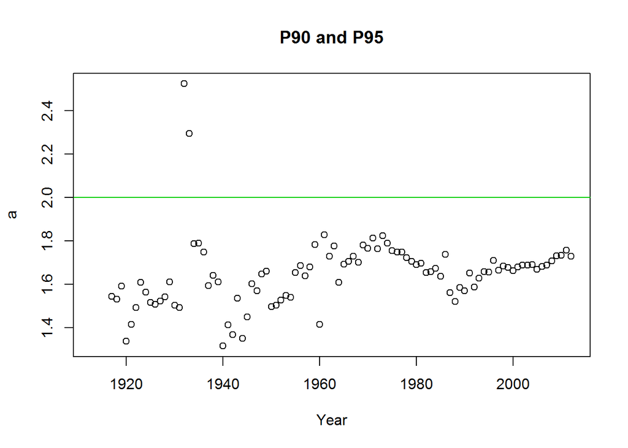

```r
plot(wtid.f$Y, func1(wtid$P90.income.threshold,wtid$P95.income.threshold,vecA$a), xlab='Year',ylab='a', main='P90 and P95')
abline(h = 2, col = "232323")
```